# Titanic_v4

```python
from IPython.core.interactiveshell import InteractiveShell
InteractiveShell.ast_node_interactivity = 'all'
import warnings
warnings.filterwarnings('ignore')
#pd.set_option("display.max_columns",50)
```

```python
import pandas as pd
import numpy as np
import matplotlib.pyplot as plt
import re
from sklearn.model_selection import train_test_split
from sklearn.linear_model import LogisticRegression
from sklearn.ensemble import RandomForestClassifier, StackingClassifier
from sklearn.preprocessing import StandardScaler,MinMaxScaler,MaxAbsScaler
from sklearn.model_selection import cross_val_score,GridSearchCV,StratifiedKFold,RepeatedStratifiedKFold,RandomizedSearchCV
from sklearn.metrics import accuracy_score,auc,recall_score,precision_score,precision_recall_curve,confusion_matrix,\
plot_confusion_matrix,plot_precision_recall_curve,plot_roc_curve,classification_report
from xgboost import XGBClassifier
from sklearn.pipeline import make_pipeline
from sklearn.svm import LinearSVC
from sklearn.neighbors import KNeighborsClassifier
#from sklearn.impute import SimpleImputer,KNNImputer
#from sklearn.compose import ColumnTransformer
```

```python
path = "C:/Users/Krishna/Documents/kaggle/titanic/input"
```

TO DO  
convert all variables to categorical  
remove outliers  
check correlation

##### Reading train csv

```python
train = pd.read_csv(f'{path}/train.csv')
train.head(2)
train.shape
```

|  | PassengerId | Survived | Pclass | Name | Sex | Age | SibSp | Parch | Ticket | Fare | Cabin | Embarked |
| --- | --- | --- | --- | --- | --- | --- | --- | --- | --- | --- | --- | --- |
| 0 | 1 | 0 | 3 | Braund, Mr. Owen Harris | male | 22.0 | 1 | 0 | A/5 21171 | 7.2500 | NaN | S |
| 1 | 2 | 1 | 1 | Cumings, Mrs. John Bradley (Florence Briggs Th... | female | 38.0 | 1 | 0 | PC 17599 | 71.2833 | C85 | C |

```
(891, 12)
```

```python
train[['Age',	'SibSp',	'Parch',	'Fare']].describe()
```

|  | Age | SibSp | Parch | Fare |
| --- | --- | --- | --- | --- |
| count | 714.000000 | 891.000000 | 891.000000 | 891.000000 |
| mean | 29.699118 | 0.523008 | 0.381594 | 32.204208 |
| std | 14.526497 | 1.102743 | 0.806057 | 49.693429 |
| min | 0.420000 | 0.000000 | 0.000000 | 0.000000 |
| 25% | 20.125000 | 0.000000 | 0.000000 | 7.910400 |
| 50% | 28.000000 | 0.000000 | 0.000000 | 14.454200 |
| 75% | 38.000000 | 1.000000 | 0.000000 | 31.000000 |
| max | 80.000000 | 8.000000 | 6.000000 | 512.329200 |

### converting numeric features into categorical

### Feature Engineering

```python
#train.Name.map(re.search("(.*)\\, (.*)\\.(.*) ").groups())
train['Surname'] = train.Name.map(str.upper).map(lambda x : re.search("(.*)\\, (.*?)\\.(.*)",x).group(2))

high_freq_surnames = train.Surname.value_counts(normalize = True)>0.04
high_freq_surnames = high_freq_surnames[high_freq_surnames!=True].index

train.Surname = np.where(~train.Surname.isin(high_freq_surnames),train.Surname,'Others')
train.Surname = np.where((train.Surname=='Others') & (train.Sex == 'male'), 'Others_male',
                         np.where((train.Surname=='Others') & (train.Sex == 'female'), 'Others_female',train.Surname))
#train.Surname.value_counts()
pd.crosstab(train.Surname,train.Survived,margins=True)
```

| Survived Surname | 0 | 1 | All |
| --- | --- | --- | --- |
| MASTER | 17 | 23 | 40 |
| MISS | 55 | 127 | 182 |
| MR | 436 | 81 | 517 |
| MRS | 26 | 99 | 125 |
| Others_female | 0 | 7 | 7 |
| Others_male | 15 | 5 | 20 |
| All | 549 | 342 | 891 |

```python
#filling na values of embarked variable
train.Embarked = np.where(train.Embarked.isna(),train.Embarked.mode(dropna=True), train.Embarked)

train.Embarked.isna().sum()
#train.Embarked.value_counts()
pd.crosstab(train.Embarked,train.Survived,margins=True)
```

```
0
```

| Survived Embarked | 0 | 1 | All |
| --- | --- | --- | --- |
| C | 75 | 93 | 168 |
| Q | 47 | 30 | 77 |
| S | 427 | 219 | 646 |
| All | 549 | 342 | 891 |

pd.crosstab(train.Parch,train.Survived,margins=True) pd.crosstab(train.SibSp,train.Survived,margins=True)

```python
train[['Age_available']] = 1*train[['Age']].notna()
train['Cabin_type'] = train.Cabin.astype(str).apply(lambda x : x[0].upper()) #N means not available
train['Family_size'] = train.Parch + train.SibSp
```

```python
np.quantile(train.Family_size,q=np.linspace(0, 1, 5),axis=0)
pd.crosstab(train.Family_size,train.Survived,margins=True)
```

```
array([ 0.,  0.,  0.,  1., 10.])
```

| Survived Family_size | 0 | 1 | All |
| --- | --- | --- | --- |
| 0 | 374 | 163 | 537 |
| 1 | 72 | 89 | 161 |
| 2 | 43 | 59 | 102 |
| 3 | 8 | 21 | 29 |
| 4 | 12 | 3 | 15 |
| 5 | 19 | 3 | 22 |
| 6 | 8 | 4 | 12 |
| 7 | 6 | 0 | 6 |
| 10 | 7 | 0 | 7 |
| All | 549 | 342 | 891 |

```python
#pd.crosstab(train.Family_size,train.Survived,margins=True)
train['Family_band'] = np.where(train.Family_size==0,'Alone',
                               np.where(train.Family_size.isin([1,2,3]),'Small',
                                       np.where(train.Family_size.isin([4,5,6]),'Medium','Large')))
pd.crosstab(train.Family_band,train.Survived,margins=True)
```

| Survived Family_band | 0 | 1 | All |
| --- | --- | --- | --- |
| Alone | 374 | 163 | 537 |
| Large | 13 | 0 | 13 |
| Medium | 39 | 10 | 49 |
| Small | 123 | 169 | 292 |
| All | 549 | 342 | 891 |

```python
#treating age
train.loc[train.Age.isna(), 'Age'] = train[train.Age.isna()].Surname.map(train.groupby('Surname').Age.mean().to_dict())
```

```python
qnt = [0,12,24,35,55,85]
train['Age_band'] = pd.cut(train['Age'], qnt,labels = ['children','teen','adult','little_old','much_old'])
pd.crosstab(train.Age_band,train.Survived,margins=True)#,normalize='index')
```

| Survived Age_band | 0 | 1 | All |
| --- | --- | --- | --- |
| children | 31 | 42 | 73 |
| teen | 144 | 100 | 244 |
| adult | 236 | 103 | 339 |
| little_old | 110 | 85 | 195 |
| much_old | 28 | 12 | 40 |
| All | 549 | 342 | 891 |

```python
#pd.crosstab(train.Age,train.Survived,margins=True)
train['Age_band'] = np.where(train.Age==0,'Alone',
                               np.where(train.Age.isin([1,2,3]),'Small',
                                       np.where(train.Age.isin([4,5,6]),'Medium','Large')))
pd.crosstab(train.Family_band,train.Survived,margins=True)
```

[output not shown]

```python
qnt = [-0.1,8,15,31,600]
train['Fare_band'] = pd.cut(train['Fare'], qnt,labels = ['good','better','best','luxury'])
pd.crosstab(train.Fare_band,train.Survived,normalize='index',margins=True)
```

| Survived Fare_band | 0 | 1 |
| --- | --- | --- |
| good | 0.784232 | 0.215768 |
| better | 0.714286 | 0.285714 |
| best | 0.530806 | 0.469194 |
| luxury | 0.418919 | 0.581081 |
| All | 0.616162 | 0.383838 |

```python
train.head(1)
```

[output not shown]

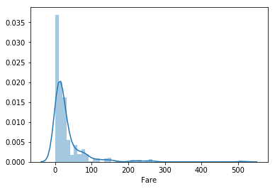

```python
import seaborn as sns
sns.distplot(train.Fare)
```

## TEST

```python
test = pd.read_csv(f'{path}/test.csv')
test.head(2)
test.shape
```

|  | PassengerId | Pclass | Name | Sex | Age | SibSp | Parch | Ticket | Fare | Cabin | Embarked |
| --- | --- | --- | --- | --- | --- | --- | --- | --- | --- | --- | --- |
| 0 | 892 | 3 | Kelly, Mr. James | male | 34.5 | 0 | 0 | 330911 | 7.8292 | NaN | Q |
| 1 | 893 | 3 | Wilkes, Mrs. James (Ellen Needs) | female | 47.0 | 1 | 0 | 363272 | 7.0000 | NaN | S |

```
(418, 11)
```

```python
test['Surname'] = test.Name.map(str.upper).map(lambda x : re.search("(.*)\\, (.*?)\\.(.*)",x).group(2))
test.Surname = np.where(test.Surname.isin(['MR','MISS','MRS','MASTER']),test.Surname,'Others')

test.Surname = np.where(~test.Surname.isin(high_freq_surnames),test.Surname,'Others')
test.Surname = np.where((test.Surname=='Others') & (test.Sex == 'male'), 'Others_male',
                         np.where((test.Surname=='Others') & (test.Sex == 'female'), 'Others_female',test.Surname))


test.Surname.isin(high_freq_surnames).value_counts()
test['Surname'].value_counts()
```

```
False    418
Name: Surname, dtype: int64
```

```
MR               240
MISS              78
MRS               72
MASTER            21
Others_male        5
Others_female      2
Name: Surname, dtype: int64
```

```python
test[['Age_available']] = 1*test[['Age']].notna()
test['Cabin_type'] = test.Cabin.astype(str).apply(lambda x : x[0].upper()) #n means not available
test['Family_size'] = test.Parch + test.SibSp
```

```python
test.Fare.isna().sum()
test['Fare'] = test.Fare.fillna(test.Fare.median())
test.Fare.isna().sum()
```

```
1
```

```
0
```

```python
#pd.crosstab(test.Family_size,test.Survived,margins=True)
test['Family_band'] = np.where(test.Family_size==0,'Alone',
                               np.where(test.Family_size.isin([1,2,3]),'Small',
                                       np.where(test.Family_size.isin([4,5,6]),'Medium','Large')))
```

```python
#treating age
test.loc[test.Age.isna(), 'Age'] = test[test.Age.isna()].Surname.map(train.groupby('Surname').Age.mean().to_dict())
```

```python
qnt = [0,12,24,35,55,85]
test['Age_band'] = pd.cut(test['Age'], qnt,labels = ['children','teen','adult','little_old','much_old'])
```

```python
#pd.crosstab(test.Age,test.Survived,margins=True)
test['Age_band'] = np.where(test.Age==0,'Alone',
                               np.where(test.Age.isin([1,2,3]),'Small',
                                       np.where(test.Age.isin([4,5,6]),'Medium','Large')))
```

```python
qnt = [-0.1,8,15,31,600]
test['Fare_band'] = pd.cut(test['Fare'], qnt,labels = ['good','better','best','luxury'])
```

```python
train.columns
test.columns
```

[output not shown]

```
Index(['PassengerId', 'Pclass', 'Name', 'Sex', 'Age', 'SibSp', 'Parch',
       'Ticket', 'Fare', 'Cabin', 'Embarked', 'Surname', 'Age_available',
       'Cabin_type', 'Family_size', 'Family_band', 'Age_band', 'Fare_band'],
      dtype='object')
```

```python
train[['Sex','Pclass', 'Embarked','Surname','Age_available','Cabin_type']] = \
train[['Sex','Pclass', 'Embarked','Surname','Age_available','Cabin_type']].astype(str)

test[['Sex','Pclass', 'Embarked','Surname','Age_available','Cabin_type']] = \
test[['Sex','Pclass', 'Embarked','Surname','Age_available','Cabin_type']].astype(str)
```

from sklearn.feature_extraction import DictVectorizer dvec = DictVectorizer(sparse=False) train_dvec = dvec.fit_transform(train[['Sex','Pclass', 'Embarked']].transpose().to_dict().values()) train_dvec = pd.DataFrame(train_dvec, index = train.index, columns = dvec.get_feature_names())

```python
def dict_vec(train_set,cols,is_test, test_set):
    """
    returns dict vectorizer on train set or train & test set for chosen columns
    train_set: Dataset on which DV is to be fit
    cols: List of columns of train_set which are to be considered for DV
    is_test: Boolean, If DV is to be transformed on test too
    test_set: Test set on which DV is to be transformed
    """
    from sklearn.feature_extraction import DictVectorizer
    import pandas as pd
    dvec = DictVectorizer(sparse=False)
    if not is_test:
        test_set = pd.DataFrame()
        train_dvec = dvec.fit_transform(train_set[cols].transpose().to_dict().values())
        train_dvec = pd.DataFrame(train_dvec, index = train_set.index, columns = dvec.get_feature_names())
        train_df = pd.concat([train_set.drop(cols, axis = 1),train_dvec], axis = 1)
        return train_df,pd.DataFrame(),dvec
    else:
        train_dvec = dvec.fit_transform(train_set[cols].transpose().to_dict().values())
        train_dvec = pd.DataFrame(train_dvec, index = train_set.index, columns = dvec.get_feature_names())
        train_df = pd.concat([train_set.drop(cols, axis = 1),train_dvec], axis = 1)
        test_dvec = dvec.transform(test_set[cols].transpose().to_dict().values())
        test_dvec = pd.DataFrame(test_dvec, index = test_set.index, columns = dvec.get_feature_names())
        test_df = pd.concat([test_set.drop(cols, axis = 1),test_dvec], axis = 1)
        return train_df, test_df,dvec
```

train_df,test_df,dv = dict_vec(train, ['Sex','Pclass', 'Embarked','Surname','Age_available','Cabin_type','Family_band', 'Age_band', 'Fare_band'],is_test = True,test_set =test)

```python
train_df,test_df,dv = dict_vec(train, ['Pclass', 'Embarked','Surname','Cabin_type','Family_band', 'Age_band', 'Fare_band'],is_test = True,test_set =test)
```

```python
train_df.columns
```

[output not shown]

```python
target  = 'Survived'
features= train_df.drop(['PassengerId','Survived', 'Name','Ticket','Cabin','SibSp', 'Parch','Sex','Age','Fare','Family_size'], axis =1).columns
target
features
```

```
'Survived'
```

```
Index(['Age_available', 'Age_band=adult', 'Age_band=children',
       'Age_band=little_old', 'Age_band=much_old', 'Age_band=teen',
       'Cabin_type=A', 'Cabin_type=B', 'Cabin_type=C', 'Cabin_type=D',
       'Cabin_type=E', 'Cabin_type=F', 'Cabin_type=G', 'Cabin_type=N',
       'Cabin_type=T', 'Embarked=C', 'Embarked=Q', 'Embarked=S',
       'Family_band=Alone', 'Family_band=Large', 'Family_band=Medium',
       'Family_band=Small', 'Fare_band=best', 'Fare_band=better',
       'Fare_band=good', 'Fare_band=luxury', 'Pclass=1', 'Pclass=2',
       'Pclass=3', 'Surname=MASTER', 'Surname=MISS', 'Surname=MR',
       'Surname=MRS', 'Surname=Others_female', 'Surname=Others_male'],
      dtype='object')
```

target = 'Survived' features= train_df.drop(['PassengerId','Survived', 'Name','Ticket','Cabin','SibSp', 'Parch'], axis =1).columns target features